# Hypothesis 1: Resting Heart Rate

## Overview of Hypothesis 1

Resting HR (RHR) changes over time during course of study

1. (Define RHR)
2. As participants’ fitness level increases, their RHR decreases
3. Participants in the aerobic activity study arm see a larger drop in RHR than those in the strength-training study arm.

### Input Variable: “Fitness Level”

TODO: definition via literature

Fitbit features that could indicate fitness level:

- BMI
- weight

TODO: Strong-D’s fitbit weight log dataset is empty, so what can we use to indicate fitness level?

### Response Variable: “Resting Heart Rate” (RHR)

TODO: definition via literature

Fitbit features that could indicate RHR:

- **fitbit’s calculation of daily resting heart rate**
  - https://help.fitbit.com/articles/en_US/Help_article/1565#resting
- heart rate during lowest intensity category
  - fitbit’s intensity value is based on MET?
- MET (https://en.wikipedia.org/wiki/Metabolic_equivalent)

This is a **continuous** response variable –> can compare different study arms using ANOVA tests.

- TODO: other analysis methods?
- TODO: look at distribution of response variable

## Import

```r
library(data.table)
library(magrittr)
library(ggplot2)
# contains commonly used functions
source("utils_custom.R")
```

## Relevant Fitbit Data

If there is previously saved data, load this data and start running chunks from the checkpoint below. (TODO: link)

```r
# per second heart rate data
# note that this is only a sample of the data since the whole dataset is too much to play around with; once I've finalized the analysis code and decided on the outputs/graphs I want, I will run the final code on the full dataset
dt_hr <- fread("data/20170801_20180927_heartrate_seconds_merged_sample_mergedAll.csv")
```

[output not shown]

```r
# daily activity data
dt_dailyActivity <- fread("data/dailyActivity_merged.csv")
# per minute intensity data
dt_intensity <- fread("data/minuteIntensitiesNarrow_merged.csv")
```

[output not shown]

## Exploratory Data Analysis

### RHR Over Time using Fitbit’s Calculated Daily RHR

```r
# extract daily RHR measurements
dt_rhr <- dt_dailyActivity[, .(Id, RestingHeartRate, ActivityDate)]
dt_rhr %>% head()
```

```
           Id RestingHeartRate ActivityDate
1: 32113-0004               NA     8/1/2017
2: 32113-0004               NA     8/2/2017
3: 32113-0004               NA     8/3/2017
4: 32113-0004               NA     8/4/2017
5: 32113-0004               NA     8/5/2017
6: 32113-0004               NA     8/6/2017
```

We have a few missing resting heart rate values, specifically:

```r
dt_rhr$RestingHeartRate %>% is.na() %>% sum() %>% divide_by(nrow(dt_rhr))
```

```
[1] 0.2635993
```

Around 26% of the daily resting heart rate measurements are missing.

- How can we impute these missing values?
- Or would it be better to use the per second heart rate measurements and use the measurements for low intensity activity as resting heart rate measurements?
  - The latter dataset has no missing values and the measurements are more precise.

```r
# convert to Date class
dt_rhr$ActivityDate <- as.Date(dt_rhr$ActivityDate, format = "%m/%d/%Y")
dt_rhr$ActivityDate %>% class()
```

```
[1] "Date"
```

```r
# list of all unique participant ids
id_list <- dt_rhr$Id %>% unique()
id_list
```

```
 [1] "32113-0004" "32113-0005" "32113-0007" "32113-0009" "32113-0011" "32113-0013"
 [7] "32113-0014" "32113-0016" "32113-0017" "32113-0018" "32113-0020" "32113-0022"
[13] "32113-0025" "32113-0026" "32113-0028" "32113-0030" "32113-0031" "32113-0032"
[19] "32113-0033" "32113-0034" "32113-0036" "32113-0038" "32113-0040" "32113-0041"
[25] "32113-0042" "32113-0044" "32113-0045" "32113-0046" "32113-0047" "32113-0048"
[31] "32113-0051" "32113-0053" "32113-0059" "32113-0060" "32113-0061" "32113-0063"
[37] "32113-0064" "32113-0065" "32113-0066" "32113-0067" "32113-0068" "32113-0070"
[43] "32113-0072" "32113-0073" "32113-0076" "32113-0078" "32113-0079" "32113-0080"
[49] "32113-0081" "32113-0082" "32113-0083" "32113-0085" "32113-0086" "32113-0089"
[55] "32113-0090" "32113-0093" "32113-0095" "32113-0097" "32113-0098" "32113-0099"
[61] "32113-0100" "32113-0106" "32113-0107" "32113-0108" "32113-0111" "32113-0112"
[67] "32113-0113" "32113-0114" "32113-0116" "32113-0118" "32113-0119" "32113-0120"
[73] "32113-0121" "32113-0123" "32113-0124" "32113-0135" "32113-0139" "32113-0142"
[79] "32113-0145"
```

*From here on, the visualizations will only use the first 5 people from `id_list` so that we don’t get too many overlapping lines (one line per person) on the plots.*

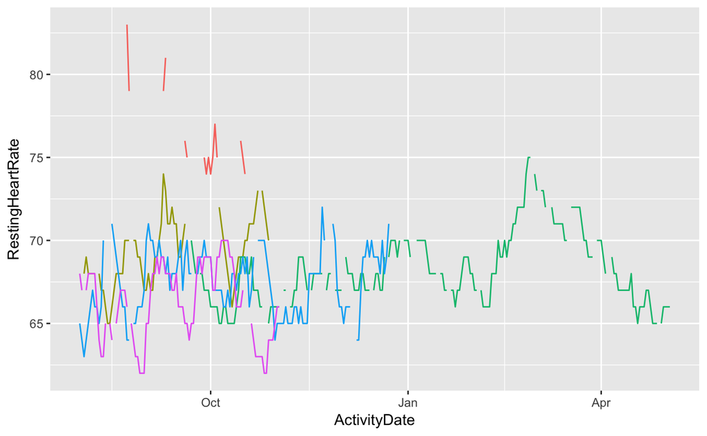

```r
# visualize resting heart rate over time for a few people
show_linePerGroup(dt_rhr[Id %in% id_list[1:5]], "ActivityDate", "RestingHeartRate", "Id")
```

```r
# (see utils_custom.R for function definition)
```

It seems like the missing data in fitbit’s daily RHR measurements is posing a problem for visualizing the RHR trends over time for each person! * TODO: instead, look at trends for per second HR (no missing data) during low intensity activity

### RHR Over Time using Raw Per Second HR and Per Minute Intensity Levels

Available data: One dataset for per minute intensity values and another dataset for per second heart rate measurements.

Goal: Interpolate per minute intensity values for each per second heart rate measurement. Then use the heart rate values corresponding to lowest intensity (intensity value 0) as RHR; plot this against time.

Intensity values have no missing values and have 4 categories (according to fitabase): * 0: Sedentary * 1: Light * 2: Moderate * 3: Very Active

```r
head(dt_intensity)
```

```
           Id       ActivityMinute Intensity
1: 32113-0004 8/1/2017 12:00:00 AM         0
2: 32113-0004 8/1/2017 12:01:00 AM         0
3: 32113-0004 8/1/2017 12:02:00 AM         0
4: 32113-0004 8/1/2017 12:03:00 AM         0
5: 32113-0004 8/1/2017 12:04:00 AM         0
6: 32113-0004 8/1/2017 12:05:00 AM         0
```

```r
dt_intensity$Intensity %>% unique()
```

```
[1] 0 1 3 2
```

```r
# TODO: fix data merging (don't merge the first line of csv files with the column names), the following is an inelegant quick fix...
dt_hr <- dt_hr[Value != "Value"]
```

We want to **interpolate the intensity category for each heart rate measurement**: join per second heart rate data with per minute intensity data by finding the temporally closest intensity category for each heart rate measurement.

```r
# convert time to POSIXct class (this can take some time...)
dt_hr$Time <- as.POSIXct(dt_hr$Time, format = "%m/%d/%Y %I:%M:%S %p")
dt_intensity$ActivityMinute <- as.POSIXct(dt_intensity$ActivityMinute, format = "%m/%d/%Y %I:%M:%S %p")
# convert heart rate values (originally character class) to numerical class
dt_hr$Value <- as.numeric(dt_hr$Value)
```

```r
# setup for join
dt_hr[, join_time := Time]
dt_intensity[, join_time := ActivityMinute]
setkey(dt_hr, Id, join_time)
setkey(dt_intensity, Id, join_time)
```

```r
# right outer join (include all measurements from dt_hr), interpolating the temporally closest intensity value/category for each HR measurement
join <- dt_intensity[dt_hr, roll = "nearest"]
# save this joined structure for quick future use
save(join, file="hr_intensity_join.RData")
```

**TODO: Saved Data Checkpoint**

**Median heart rate per intensity category:** TODO: calculate quartiles to make box plots

```r
dt_hr_allIntensity <- join[, .(Id, Time, Value, Intensity)]
dt_hr_allIntensity %>% head()
```

```
           Id                Time Value Intensity
1: 32113-0004 2017-08-01 04:46:50    70         0
2: 32113-0004 2017-08-01 04:47:28    70         0
3: 32113-0004 2017-08-01 04:47:38    70         1
4: 32113-0004 2017-08-01 04:47:51    70         1
5: 32113-0004 2017-08-01 04:48:37    89         1
6: 32113-0004 2017-08-01 04:49:07    94         1
```

```r
medianHR_perIntensity <- dt_hr_allIntensity[, .(medianHR = median(Value)), by=Intensity]
medianHR_perIntensity
```

```
   Intensity medianHR
1:         0       72
2:         1       88
3:         3      116
4:         2      106
```

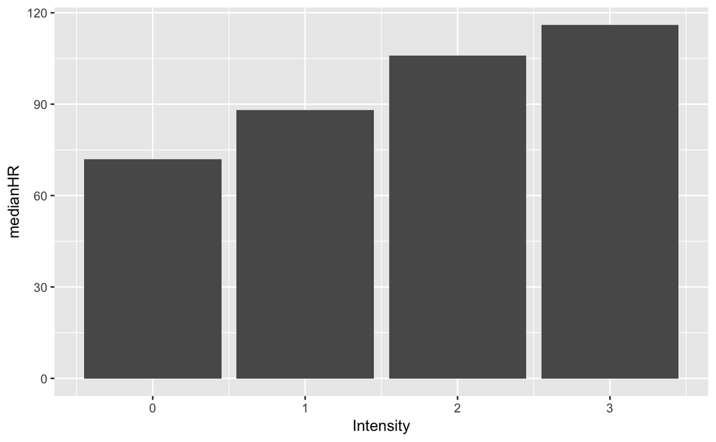

```r
ggplot(data = medianHR_perIntensity) +
  geom_bar(stat = "identity", mapping = aes(x = Intensity, y = medianHR))
```

**Delta median heart rate between highest and lowest intensity category per participant:** TODO: calculate quartiles to make box plots

```r
# it is possible that some participants never have an intensity value in the highest/lowest intensity category and therefore are not included in the following tables
medianHR_highIntensity_perId <- dt_hr_allIntensity[Intensity == "3", .(medianHR_high = median(Value)), by = Id]
medianHR_lowIntensity_perId <- dt_hr_allIntensity[Intensity == "0", .(medianHR_low = median(Value)), by = Id]
# inner join
setkey(medianHR_highIntensity_perId, Id)
setkey(medianHR_lowIntensity_perId, Id)
deltaHR_perId <- medianHR_highIntensity_perId[medianHR_lowIntensity_perId, nomatch = 0]
deltaHR_perId[, deltaHR := (medianHR_high - medianHR_low)]
deltaHR_perId %>% head()
```

```
           Id medianHR_high medianHR_low deltaHR
1: 32113-0004           129           82      47
2: 32113-0005           133           76      57
3: 32113-0007           108           78      30
4: 32113-0009           112           73      39
5: 32113-0011           129           71      58
6: 32113-0013           118           78      40
```

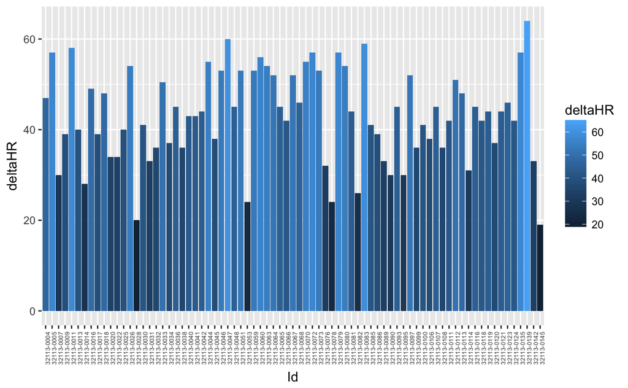

```r
ggplot(data = deltaHR_perId) +
  geom_bar(stat = "identity", mapping = aes(x = Id, y = deltaHR, fill = deltaHR)) +
  theme(axis.text.x = element_text(angle = 90, size=5))
```

**RHR (heart rate values during lowest intensity category) over time:**

```r
# focus on (resting) HR during lowest intensity category (0: sedentary)
dt_hr_lowIntensity <- join[Intensity == 0][, .(Id, Time, Value)]
```

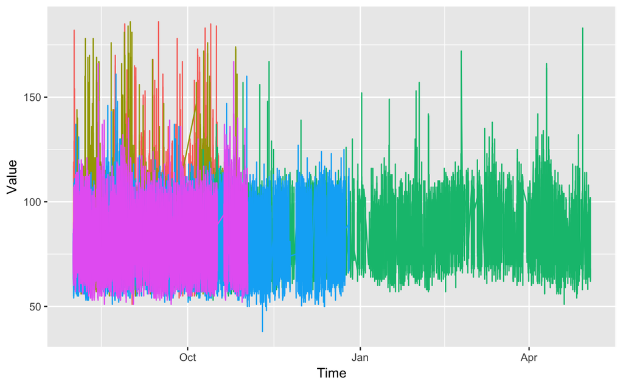

```r
# visualize resting resting heart rate over time for a few people
show_linePerGroup(dt_hr_lowIntensity[Id %in% id_list[1:5]], "Time", "Value", "Id")
```

There’s too much noise/variance when we look at the just the per second raw HR values. Let’s instead use aggregate values, such as minimum (since we’re interested in resting/low heart rate values) or median (resistant to noise), over a some time window size, such as one day.

```r
# create a column that indicates the day of each measurement
dt_hr_lowIntensity[, day := as.Date(Time)]
# aggregation, e.g. daily minimum RHR per person
dt_hr_lowIntensity[, .(minHR_day = min(Value)), by = .(Id, day)]
```

```
               Id        day minHR_day
    1: 32113-0004 2017-08-01        65
    2: 32113-0004 2017-08-02        62
    3: 32113-0004 2017-08-03        70
    4: 32113-0004 2017-08-22        70
    5: 32113-0004 2017-08-23        65
   ---
10459: 32113-0145 2018-09-17        70
10460: 32113-0145 2018-09-18        70
10461: 32113-0145 2018-09-19        70
10462: 32113-0145 2018-09-20        70
10463: 32113-0145 2018-09-21        70
```

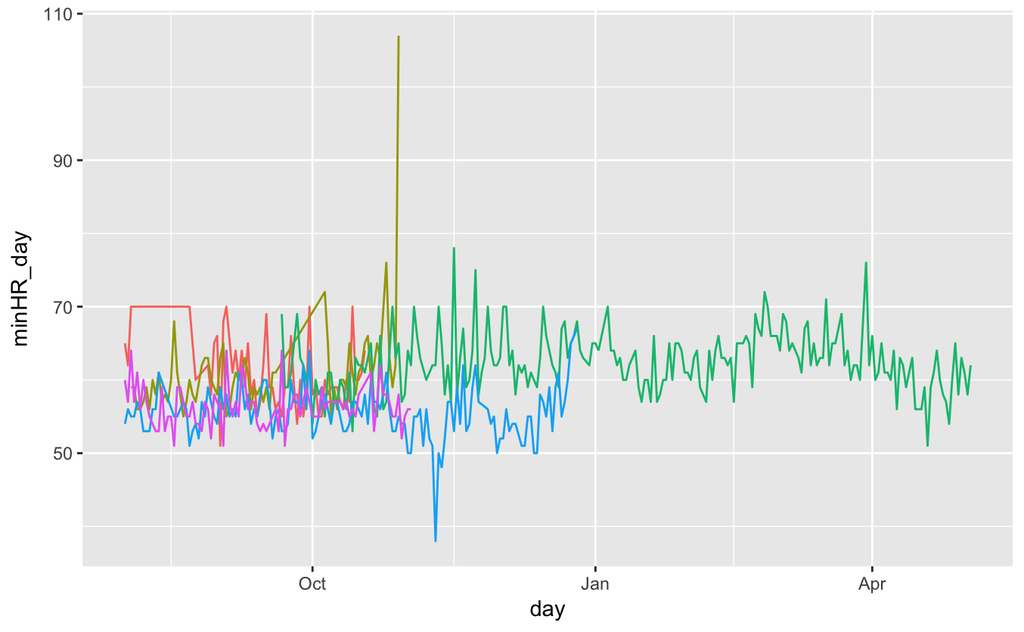

```r
# daily minimum low intensity HR over time for a few people
show_linePerGroup(dt_hr_lowIntensity[Id %in% id_list[1:5], .(minHR_day = min(Value)), by = .(Id, day)], "day", "minHR_day", "Id")
```

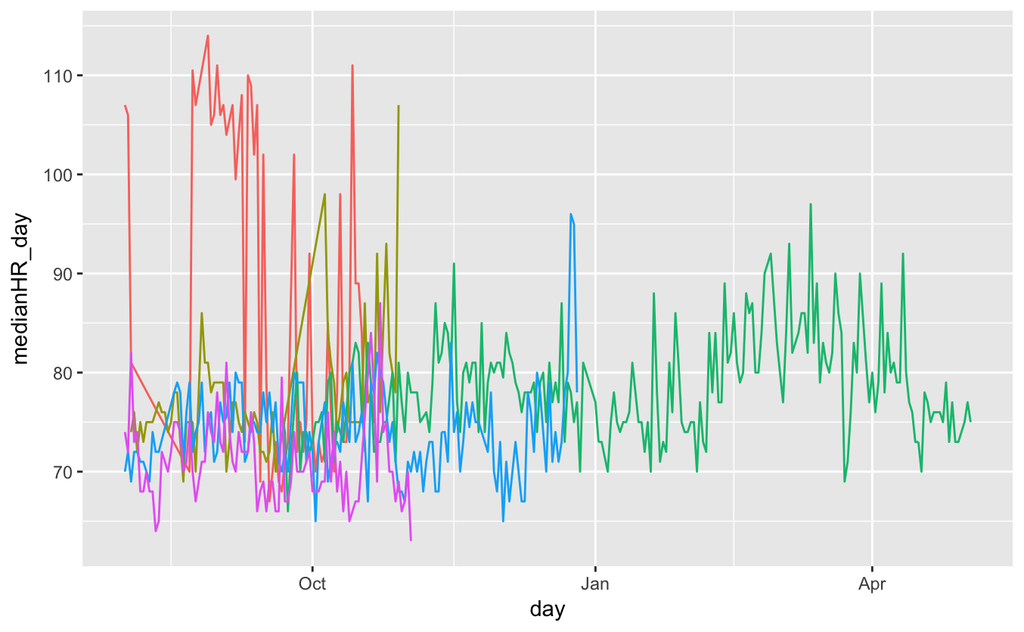

```r
# daily median low intensity HR over time for a few people
show_linePerGroup(dt_hr_lowIntensity[Id %in% id_list[1:5], .(medianHR_day = median(Value)), by = .(Id, day)], "day", "medianHR_day", "Id")
```

```r
# TODO: data.table rolling join where we find the closest fitness level to each resting heart rate measurement
```